# Zara Sales & Seasonality Analysis Case Study

Daijah B

2025-07-22

# Introduction

My client is a global fast fashion retailer that operates in the apparel industry, known for quickly responding to runway and street fashion trends. They specialize in rapid product turnaround, limited stock releases, and trend-driven inventory cycles. The company has asked me to analyze product performance and seasonal sales trends to better understand how pricing strategies, product categories, and seasonal demand affect overall sales. These insights will help improve their merchandising, marketing, and inventory decisions for future fashion cycles.

# Business Problem and Key Factors

Key factors include seasonal demand patterns, price fluctuation by product category, and shifts in consumer interest throughout the year. I am analyzing which product types sell faster in different seasons, how pricing changes (e.g., discounts, sales) influence performance, and how these patterns align with Zara’s fast fashion model. These insights can support better timing for product drops, clearance strategies, and targeted promotions.

# Data Description

The data used in this analysis comes from a public datasheet containing product-level sales information for Zara. It includes variables such as product ID, category, seasonality indicator, promotion status, sales volume, product position within the store, price, and other product attributes. The dataset contains 252 records covering multiple product types, seasonal flags, and promotional activities, enabling a comprehensive look at sales trends by season and store placement.

# Methods

# Analysis

## Average Sales by Product Position and Seasonality

```r
library(tidyverse)
zara <- read_delim("zara.csv", delim = ";", skip = 1, col_names = c(
  "Product ID", "Product Position", "Promotion", "Product Category",
  "Seasonal", "Sales Volume", "brand", "url", "sku", "name",
  "description", "price", "currency", "scraped_at", "terms", "section"
), trim_ws = TRUE)
colnames(zara)
```

```
##  [1] "Product ID"       "Product Position" "Promotion"        "Product Category"
##  [5] "Seasonal"         "Sales Volume"     "brand"            "url"
##  [9] "sku"              "name"             "description"      "price"
## [13] "currency"         "scraped_at"       "terms"            "section"
```

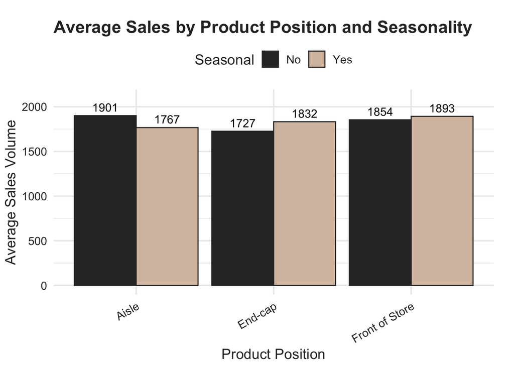

```r
zara_summary <- zara %>%
  group_by(Seasonal, `Product Position`) %>%
  summarise(Average_Sales = mean(`Sales Volume`, na.rm = TRUE)) %>%
  arrange(Seasonal, desc(Average_Sales))

ggplot(zara_summary, aes(x = `Product Position`, y = Average_Sales, fill = Seasonal)) +
  geom_col(position = "dodge", color = "#2E2E2E") +
  geom_text(aes(label = round(Average_Sales)),
            position = position_dodge(width = 0.9), vjust = -0.5,
            color = "black", size = 4) +
  scale_fill_manual(values = c("No" = "#2E2E2E", "Yes" = "#D7BFAE")) +
  labs(
    title = "Average Sales by Product Position and Seasonality",
    x = "Product Position",
    y = "Average Sales Volume",
    fill = "Seasonal"
  ) +
  theme_minimal(base_size = 14) +
  theme(
    text = element_text(color = "#2E2E2E"),
    axis.text = element_text(color = "#2E2E2E"),
    axis.title = element_text(color = "#2E2E2E"),
    legend.position = "top",
    plot.title = element_text(face = "bold", color = "#2E2E2E"),
    axis.text.x = element_text(angle = 30, hjust = 1),
    plot.margin = margin(t = 20, r = 20, b = 5, l = 5)
  ) +
  coord_cartesian(ylim = c(0, max(zara_summary$Average_Sales) * 1.1), clip = "off")
```

## Effect of Promotion on Sales by Seasonality

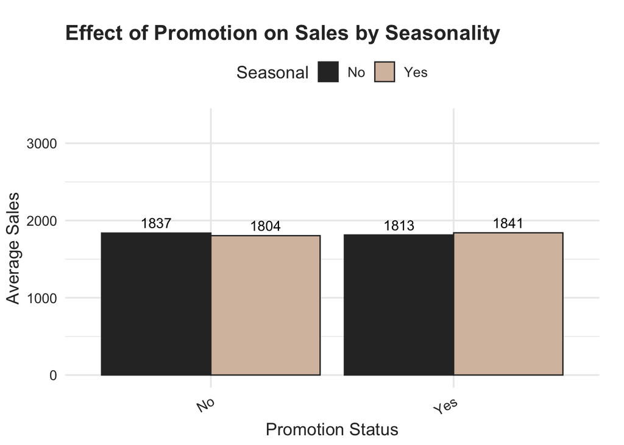

```r
zara %>%
  group_by(Seasonal, Promotion) %>%
  summarise(Average_Sales = mean(`Sales Volume`, na.rm = TRUE)) %>%
  arrange(Seasonal, Promotion) %>%
  ggplot(aes(x = Promotion, y = Average_Sales, fill = Seasonal)) +
  geom_col(position = "dodge", color = "#2E2E2E") +
  geom_text(aes(label = round(Average_Sales, 0)),
            position = position_dodge(width = 0.9),
            vjust = -0.5, color = "black", size = 4) +
  scale_fill_manual(values = c("No" = "#2E2E2E", "Yes" = "#D7BFAE")) +
  theme_minimal(base_size = 14) +
  theme(
    text = element_text(color = "#2E2E2E"),
    axis.text = element_text(color = "#2E2E2E"),
    axis.title = element_text(color = "#2E2E2E"),
    legend.position = "top",
    plot.title = element_text(face = "bold"),
    axis.text.x = element_text(angle = 30, hjust = 1),
    plot.margin = margin(t = 20, r = 20, b = 5, l = 5)
  ) +
  labs(
    title = "Effect of Promotion on Sales by Seasonality",
    x = "Promotion Status",
    y = "Average Sales",
    fill = "Seasonal"
  ) +
  coord_cartesian(clip = "off") +
  ylim(0, max(zara$`Sales Volume`, na.rm = TRUE) * 1.1)
```

# Recommendations Zara should prioritize placing seasonal products in high-visibility areas like the front of the store to capitalize on increased consumer interest during peak seasons. Non-seasonal products can be effectively placed in aisles where they consistently generate strong sales.

Promotional campaigns should focus more on seasonal merchandise, as promotions have a greater impact on driving sales during these periods. Tailored discounts or limited-time offers on seasonal items can help boost demand and clear inventory efficiently.

Coordination between merchandising and marketing teams is essential to align product launches, promotions, and store layouts with seasonal trends. Using data-driven insights can improve timing and targeting for campaigns.

Continuous tracking of sales performance by product category, placement, and promotion will allow Zara to refine strategies dynamically, ensuring responsiveness to changing consumer behaviors and market conditions.

# Conclusion

This analysis demonstrates how Zara can take advantage of data on seasonality, product placement, and promotions to improve their sales performance. more in-depth analyses with larger datasets and real-time sales tracking will help Zara stay competitive and responsive in the fast-paced fashion industry.